# Task 1 – Curse of dimensionality and effect of sample size

## For D from 1 to 15 dimensions, simulate 1000 random D-dimensional points, where the value in each dimension is uniformly randomly distributed between -1 and +1.

## a) Calculate the fraction of these points that are within distance 1 of the origin, giving an approximation of the volume of the unit hypersphere to the hypercube inscribing it. Plot this fraction as a function of D (a scatter plot of D versus the fraction).

```python
import numpy as np
dimension=15
num_points=1000
fractions=[]
for i in range(1,dimension+1):
    points = np.random.uniform(low=-1.0,high=1.0,size=(num_points,i))
    distances=np.linalg.norm(points, axis=1)
    fractions.append(np.sum(distances<1)/len(distances))
```

```python
fractions=[]
for i in range(1,dimension+1):
    points = np.random.uniform(low=-1.0,high=1.0,size=(num_points,i))
    distances=np.linalg.norm(points, axis=1)
    fractions.append(np.sum(distances<1)/len(distances))
```

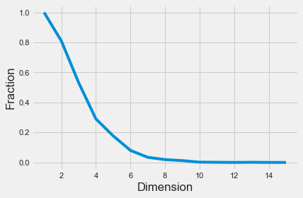

```python
import matplotlib.pyplot as plt
plt.style.use('fivethirtyeight')
import matplotlib.image as mpimg
plt.plot(np.arange(1,16,1),fractions)
plt.xlabel("Dimension")
plt.ylabel("Fraction")
```

## b) Use the value of this fraction at D = 2 and D = 3 to get estimates for the value of pi (Π) as you know the area (for D = 2) and volume (for D = 3) formulae for these cases.

```python
#For D=2
print("Pi is ", 4*fractions[1],"for D=2")
```

```
Pi is  3.24 for D=2
```

```python
#For D=3
print("Pi is ", 6*fractions[2],"for D=3")
```

```
Pi is  3.192 for D=3
```

```python
num_points=[5000, 10000, 25000, 50000, 100000]
fractions=[]
fractions_D2=[]
fractions_D3=[]
for i in num_points:
    for j in range(2,4):
        points = np.random.uniform(low=-1.0,high=1.0,size=(i,j))
        distances=np.linalg.norm(points, axis=1)
        fractions.append(np.sum(distances<1)/len(distances))
for i in range(len(fractions)):
    if i%2==0:
        fractions_D2.append(fractions[i])
    else:
        fractions_D3.append(fractions[i])
est_D2=[element * 4 for element in fractions_D2]
est_D3=[element * 6 for element in fractions_D3]
```

```python
import pandas as pd
import seaborn as sns
sns.set_theme(style="whitegrid")
```

```python
data = pd.DataFrame({'DataPoints' : num_points,
                                'Estimation for D=2' : est_D2,
                                'Estimation for D=3' : est_D3 },
                                columns=['DataPoints','Estimation for D=2', 'Estimation for D=3'])
data=data.set_index('DataPoints')
data
```

| DataPoints | Estimation for D=2 | Estimation for D=3 |
| --- | --- | --- |
| 5000 | 3.13280 | 3.09240 |
| 10000 | 3.14160 | 3.20340 |
| 25000 | 3.14128 | 3.16248 |
| 50000 | 3.14024 | 3.13740 |
| 100000 | 3.14024 | 3.15738 |

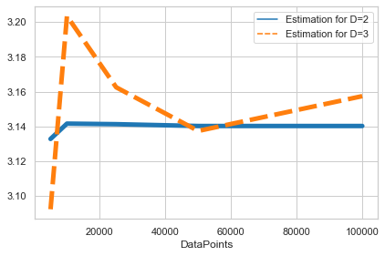

```python
sns.lineplot(data=data,palette="tab10", linewidth=5)
```

```python
import numpy as np
dimension=15
num_points=1000
test_num_points=100
fractions=[]

for i in range(1,dimension+1):
    points = np.random.uniform(low=-1.0,high=1.0,size=(num_points,i))
    test_points = np.random.uniform(low=-1.0,high=1.0,size=(test_num_points,i))
```

```python
test_points[99,10]
```

```
-0.01627097374143327
```

```python
def nearest_neighbors(value, array, nbr_neighbors=1):
    return np.argsort(np.array([np.linalg.norm(value-x) for x in array]))[:nbr_neighbors]
```

# Task 2 – Practicing data manipulation skills on images

## a) Read image as a variable in R/Python. You need to install “jpeg” package to read image into a variable if you use R. For Python, an alternative is to use matplotlib package. What is the structure of the variable that stores the image? What is the dimension? a. Display the image

```
Structure:  <class 'numpy.ndarray'>
# of dims:  3
Img shape:  (512, 512, 3)
Dtype:  uint8
```

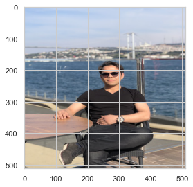

```python
import matplotlib.image as mpimg
img=mpimg.imread('IMG.jpg')
imgplot=plt.imshow(img)
print('Structure: ',type(img))
print('# of dims: ',img.ndim)
print('Img shape: ',img.shape)
print('Dtype: ',img.dtype)
plt.show()
```

## b) Display each channel as separate image

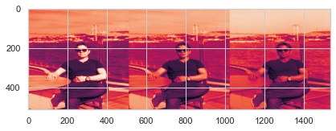

```python
channel_0 = img.copy()
channel_0 =channel_0[:, :, 0]
channel_1 = img.copy()
channel_1 =channel_1[:, :, 1]
channel_2 = img.copy()
channel_2 =channel_2[:, :, 2]

channels = np.concatenate((channel_0, channel_1, channel_2), axis=1)
im_RGB = np.hstack((channel_0, channel_1, channel_2))
im_RGB = np.c_['1', channel_0, channel_1, channel_2]
plt.imshow(im_RGB)
plt.show()
```

## c) For each channel, take the average of the columns and plot the average as a line plot for each channel on a single plot.

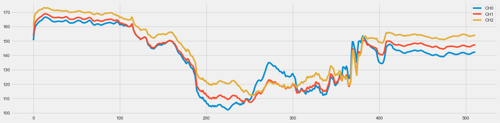

```python
plt.style.use('fivethirtyeight')
plt.figure(figsize=(20,5))
for i in range(3):
    channel = img[:,:, i]
    col_avg = np.mean(channel, axis = 0)
    plt.plot(list(range(col_avg.shape[0])), col_avg, label=f"CH{i}")
plt.legend()
plt.show()
```

## d) For each channel, subtract one half of the image from the other half (choice of halves is up to you but dividing the head image vertically into two parts make more sense). If you observe negative pixel values, you can make them equal to zero. Then:

## • Display the new image.

## • Display each channel separately as separate image.

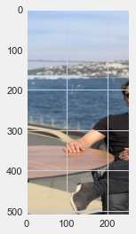

```python
half=img.shape[1]//2
left_half=img[:,:half,:]

plt.imshow(left_half)
```

```
channel 0
```

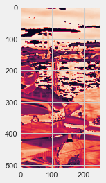

```
channel 1
```

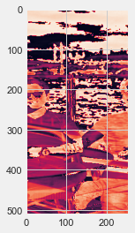

```
channel 2
```

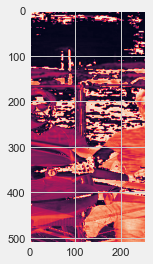

```
all channels
```

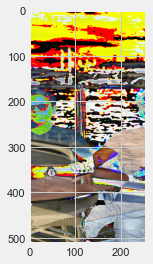

```python
half=img.shape[1]//2
left_half=img[:,:half,:]
right_half=img[:,half:,:]
left_half=left_half-right_half
left_half=left_half.clip(min=0)
print('channel 0')
plt.imshow(left_half[:,:,0])
plt.show()
print('channel 1')
plt.imshow(left_half[:,:,1])
plt.show()
print('channel 2')
plt.imshow(left_half[:,:,2])
plt.show()
print('all channels')
plt.imshow(left_half)
plt.show()
```

## e) In order to create a noisy image, add a random noise from uniform distribution with minimum value of 0 and a maximum value of “0.1 * maximum pixel value observed” to each pixel value for each channel of original image. • Display the new image. • Display each channel separately as separate image.

```
channel 0
```

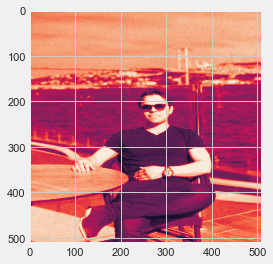

```
channel 1
```

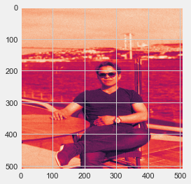

```
channel 2
```

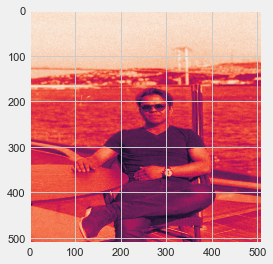

```
all channels
```

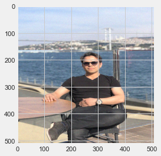

```python
noise = np.random.uniform(0, 0.1*np.max(img), size=img.shape)
noisy_image=noise+img
noisy_image=noisy_image.clip(0,255).astype(int)
print('channel 0')
plt.imshow(noisy_image[:,:,0])
plt.show()
print('channel 1')
plt.imshow(noisy_image[:,:,1])
plt.show()
print('channel 2')
plt.imshow(noisy_image[:,:,2])
plt.show()
print('all channels')
plt.imshow(noisy_image[:,:,:])
plt.show()
```